# Project - Unsupervised Learning

## Project - AllLife Credit Card Customer Segmentation

```
- Amarpreet Bassan
```

### Assumptions

- The machine has missingno package installed.
- The machine has anaconda installed.
- The data file : Credit Card Customer Data.xlsx is in teh same folder.
1. Assumptions
2. Import Section
3. Dataset Info Observation:)
4. Exploratory Data Analysis
5. Observation on Data Analysis
6. K Means
   - Selection of Clusters
   - Recommendations based on K means clustering
7. Hierarchical Clustering
   - Observations based on Dendrogram
   - Observations on Coefficients
   - Observations on Hierarchical Clustering
   - Recommendations based on Hierarchical Clustering
8. Comparison Between Clusters

#### Import Section

```python
import pandas as pd
import numpy as np
import matplotlib.pyplot as plt
import seaborn as sns
pd.options.display.float_format = '{:4f}'.format
import missingno as msno
from sklearn import preprocessing

from sklearn.cluster import KMeans
from scipy.spatial.distance import cdist
from sklearn.metrics import silhouette_score
from sklearn.cluster import AgglomerativeClustering
from scipy.cluster.hierarchy import linkage
from scipy.cluster.hierarchy import cophenet
from scipy.spatial.distance import pdist
from scipy.cluster.hierarchy import dendrogram
import scipy.cluster.hierarchy as sch
```

```python
#create Analytics base table
abt = pd.read_excel("Credit Card Customer Data.xlsx")
```

```python
#create a copy of the analytics base table to work on.
wdf = abt.copy()
```

```python
#change the index column to Serial number
wdf.set_index('Sl_No', inplace = True)
```

```python
#get information about all the columns
wdf.info()
```

```
<class 'pandas.core.frame.DataFrame'>
Int64Index: 660 entries, 1 to 660
Data columns (total 6 columns):
 #   Column               Non-Null Count  Dtype
---  ------               --------------  -----
 0   Customer Key         660 non-null    int64
 1   Avg_Credit_Limit     660 non-null    int64
 2   Total_Credit_Cards   660 non-null    int64
 3   Total_visits_bank    660 non-null    int64
 4   Total_visits_online  660 non-null    int64
 5   Total_calls_made     660 non-null    int64
dtypes: int64(6)
memory usage: 36.1 KB
```

#### Obseration on Dataset(info):

1. All of the columns are numerical.
2. customer key seems to be a unique identifier for each customer.

#### Analysis - EDA, Visualization and Data Exploration

```python
#check first 5 rows
wdf.head()
```

| Sl_No | Customer Key | Avg_Credit_Limit | Total_Credit_Cards | Total_visits_bank | Total_visits_online | Total_calls_made |
| --- | --- | --- | --- | --- | --- | --- |
| 1 | 87073 | 100000 | 2 | 1 | 1 | 0 |
| 2 | 38414 | 50000 | 3 | 0 | 10 | 9 |
| 3 | 17341 | 50000 | 7 | 1 | 3 | 4 |
| 4 | 40496 | 30000 | 5 | 1 | 1 | 4 |
| 5 | 47437 | 100000 | 6 | 0 | 12 | 3 |

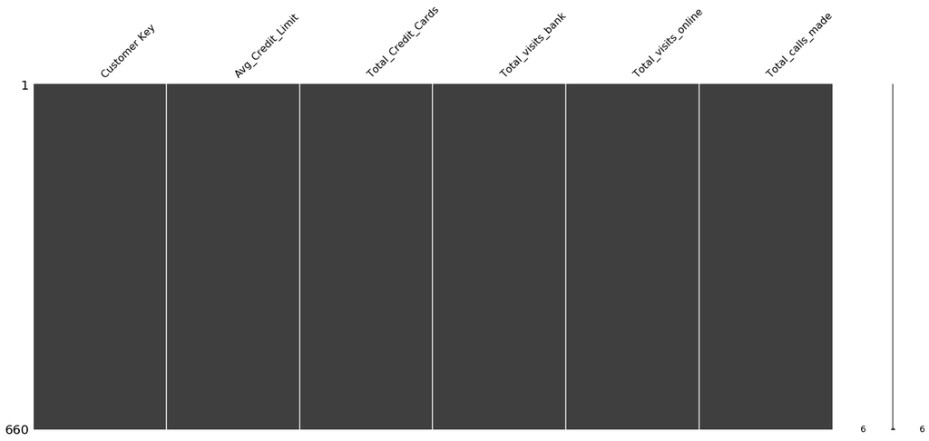

```python
#let us check if there are any missing values
msno.matrix(wdf)

#Observation :
#no missing data observed.
```

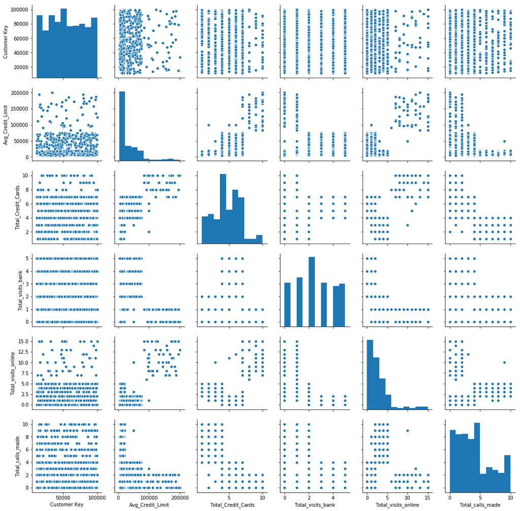

```python
#let us explore the pair plot of the data
sns.pairplot(wdf)
```